### TupleTransform

`class` `TupleTransform`[[source]](https://github.com/fastai/fastai2/tree/master/fastai2/core/transform.py#L111)

> `TupleTransform`(**`enc`**=*`None`*, **`dec`**=*`None`*, **`split_idx`**=*`None`*, **`as_item`**=*`False`*, **`order`**=*`None`*) :: `Transform`

`Transform` that always treats `as_item` as `False`

`class` `ItemTransform`[[source]](https://github.com/fastai/fastai2/tree/master/fastai2/core/transform.py#L116)

> `ItemTransform`(**`enc`**=*`None`*, **`dec`**=*`None`*, **`split_idx`**=*`None`*, **`as_item`**=*`False`*, **`order`**=*`None`*) :: `Transform`

`Transform` that always treats `as_item` as `True`

```python
def float_to_int(x:(float,int)): return Int(x)

f = TupleTransform(float_to_int)
test_eq_type(f([1.]), (Int(1),))
test_eq_type(f([1]), (Int(1),))
test_eq_type(f(['1']), ('1',))
test_eq_type(f([1,'1']), (Int(1),'1'))
test_eq(f.decode([1]), [1])

test_eq_type(f(Tuple(1.)), Tuple(Int(1)))
```

```python
class B(TupleTransform): pass
class C(TupleTransform): pass
f = B()
test_eq(f([1]), [1])
```

```python
@B
def encodes(self, x:int): return x+1
@B
def encodes(self, x:str): return x+'1'
@B
def encodes(self, x)->None: return str(x)+'!'

b,c = B(),C()
test_eq(b([1]), [2])
test_eq(b(['1']), ('11',))
test_eq(b([1.0]), ('1.0!',))
test_eq(c([1]), [1])
test_eq(b([1,2]), (2,3))
test_eq(b.decode([2]), [2])
assert pickle.loads(pickle.dumps(b))
```

```python
@B
def decodes(self, x:int): return x-1
test_eq(b.decode([2]), [1])
test_eq(b.decode(('2',)), ('2',))
```

Non-type-constrained functions are applied to all elements of a tuple.

```python
class A(TupleTransform): pass
@A
def encodes(self, x): return x+1
@A
def decodes(self, x): return x-1

f = A()
t = f((1,2.0))
test_eq_type(t, (2,3.0))
test_eq_type(f.decode(t), (1,2.0))
```

Type-constrained functions are applied to only matching elements of a tuple, and return annotations are only applied where matching.

```python
class B(TupleTransform):
    def encodes(self, x:int): return Int(x+1)
    def encodes(self, x:str): return x+'1'
    def decodes(self, x:Int): return x//2

f = B()
start = (1.,2,'3')
t = f(start)
test_eq_type(t, (1.,Int(3),'31'))
test_eq(f.decode(t), (1.,Int(1),'31'))
```

The same behavior also works with `typing` module type classes.

```python
class A(Transform): pass
@A
def encodes(self, x:numbers.Integral): return x+1
@A
def encodes(self, x:float): return x*3
@A
def decodes(self, x:int): return x-1

f = A()
start = 1.0
t = f(start)
test_eq(t, 3.)
test_eq(f.decode(t), 3)

f = A(as_item=False)
start = (1.,2,3.)
t = f(start)
test_eq(t, (3.,3,9.))
test_eq(f.decode(t), (3.,2,9.))
```

Transform accepts lists

```python
def a(x): return L(x_+1 for x_ in x)
def b(x): return L(x_-1 for x_ in x)
f = TupleTransform(a,b)

t = f((L(1,2),))
test_eq(t, (L(2,3),))
test_eq(f.decode(t), (L(1,2),))
```

`get_func`[[source]](https://github.com/fastai/fastai2/tree/master/fastai2/core/transform.py#L121)

> `get_func`(**`t`**, **`name`**, *`args`, **`kwargs`)

Get the `t.name` (potentially partial-ized with `args` and `kwargs`) or `noop` if not defined

This works for any kind of `t` supporting `getattr`, so a class or a module.

```python
test_eq(get_func(operator, 'neg', 2)(), -2)
test_eq(get_func(operator.neg, '__call__')(2), -2)
test_eq(get_func(list, 'foobar')([2]), [2])
t = get_func(torch, 'zeros', dtype=torch.int64)(5)
test_eq(t.dtype, torch.int64)
a = [2,1]
get_func(list, 'sort')(a)
test_eq(a, [1,2])
```

Transforms are built with multiple-dispatch: a given function can have several methods depending on the type of the object received. This is done directly with the `TypeDispatch` module and type-annotation in `Transform`, but you can also use the following class.

`class` `Func`[[source]](https://github.com/fastai/fastai2/tree/master/fastai2/core/transform.py#L127)

> `Func`(**`name`**, *`args`, **`kwargs`)

Basic wrapper around a `name` with `args` and `kwargs` to call on a given type

You can call the `Func` object on any module name or type, even a list of types. It will return the corresponding function (with a default to `noop` if nothing is found) or list of functions.

```python
test_eq(Func('sqrt')(math), math.sqrt)
test_eq(Func('sqrt')(torch), torch.sqrt)

@patch
def powx(x:math, a): return math.pow(x,a)
@patch
def powx(x:torch, a): return torch.pow(x,a)
tst = Func('powx',a=2)([math, torch])
test_eq([f.func for f in tst], [math.powx, torch.powx])
for t in tst: test_eq(t.keywords, {'a': 2})
```

`Sig`[[source]](https://github.com/fastai/fastai2/tree/master/fastai2/core/transform.py#L137)

> `Sig`(*`args`, **`kwargs`)

`Sig` is just sugar-syntax to create a `Func` object more easily with the syntax `Sig.name(*args, **kwargs)`).

```python
f = Sig.sqrt()
test_eq(f(math), math.sqrt)
test_eq(f(torch), torch.sqrt)
```

`compose_tfms`[[source]](https://github.com/fastai/fastai2/tree/master/fastai2/core/transform.py#L143)

> `compose_tfms`(**`x`**, **`tfms`**, **`is_enc`**=*`True`*, **`reverse`**=*`False`*, **`kwargs`)

Apply all `func_nm` attribute of `tfms` on `x`, maybe in `reverse` order

```python
def to_int  (x):   return Int(x)
def to_float(x):   return Float(x)
def double  (x):   return x*2
def half(x)->None: return x/2
```

```python
def test_compose(a, b, *fs): test_eq_type(compose_tfms(a, tfms=map(Transform,fs)), b)

test_compose(1,   Int(1),   to_int)
test_compose(1,   Float(1), to_int,to_float)
test_compose(1,   Float(2), to_int,to_float,double)
test_compose(2.0, 2.0,      to_int,double,half)
```

```python
class A(Transform):
    def encodes(self, x:float):  return Float(x+1)
    def decodes(self, x): return x-1

tfms = [A(), Transform(math.sqrt)]
t = compose_tfms(3., tfms=tfms)
test_eq_type(t, Float(2.))
test_eq(compose_tfms(t, tfms=tfms, is_enc=False), 1.)
test_eq(compose_tfms(4., tfms=tfms, reverse=True), 3.)
```

```python
tfms = [A(as_item=False), Transform(math.sqrt, as_item=False)]
test_eq(compose_tfms((9,3.), tfms=tfms), (3,2.))
```

`mk_transform`[[source]](https://github.com/fastai/fastai2/tree/master/fastai2/core/transform.py#L152)

> `mk_transform`(**`f`**, **`as_item`**=*`True`*)

Convert function `f` to `Transform` if it isn't already one

```python
def neg(x): return -x
test_eq(type(mk_transform(neg)), Transform)
test_eq(type(mk_transform(math.sqrt)), Transform)
test_eq(type(mk_transform(lambda a:a*2)), Transform)
```

`gather_attrs`[[source]](https://github.com/fastai/fastai2/tree/master/fastai2/core/transform.py#L158)

> `gather_attrs`(**`o`**, **`k`**, **`nm`**)

Used in **getattr** to collect all attrs `k` from `self.{nm}`

`gather_attr_names`[[source]](https://github.com/fastai/fastai2/tree/master/fastai2/core/transform.py#L167)

> `gather_attr_names`(**`o`**, **`nm`**)

Used in **dir** to collect all attrs `k` from `self.{nm}`

`class` `Pipeline`[[source]](https://github.com/fastai/fastai2/tree/master/fastai2/core/transform.py#L172)

> `Pipeline`(**`funcs`**=*`None`*, **`as_item`**=*`False`*, **`split_idx`**=*`None`*)

A pipeline of composed (for encode/decode) transforms, setup with types

```python
add_docs(Pipeline,
         __call__="Compose `__call__` of all `fs` on `o`",
         decode="Compose `decode` of all `fs` on `o`",
         show="Show `o`, a single item from a tuple, decoding as needed",
         add="Add transform `t`",
         set_as_item="Set value of `as_item` for all transforms",
         setup="Call each tfm's `setup` in order")
```

`Pipeline` is a wrapper for `compose_tfm`. You can pass instances of `Transform` or regular functions in `funcs`, the `Pipeline` will wrap them all in `Transform` (and instantiate them if needed) during the initialization. It handles the transform `setup` by adding them one at a time and calling setup on each, goes through them in order in `__call__` or `decode` and can `show` an object by applying decoding the transforms up until the point it gets an object that knows how to show itself.

```python
# Empty pipeline is noop
pipe = Pipeline()
test_eq(pipe(1), 1)
pipe.set_as_item(False)
test_eq(pipe((1,)), (1,))
# Check pickle works
assert pickle.loads(pickle.dumps(pipe))
```

```python
class IntFloatTfm(Transform):
    def encodes(self, x):  return Int(x)
    def decodes(self, x):  return Float(x)
    foo=1

int_tfm=IntFloatTfm()

def neg(x): return -x
neg_tfm = Transform(neg, neg)
```

```python
pipe = Pipeline([neg_tfm, int_tfm])

start = 2.0
t = pipe(start)
test_eq_type(t, Int(-2))
test_eq_type(pipe.decode(t), Float(start))
test_stdout(lambda:pipe.show(t), '-2')

pipe.set_as_item(False)
test_stdout(lambda:pipe.show(pipe((1.,2.))), '-1\n-2')
test_eq(pipe.foo, 1)
assert 'foo' in dir(pipe)
assert 'int_float_tfm' in dir(pipe)
```

Transforms are available as attributes named with the snake_case version of the names of their types. Attributes in transforms can be directly accessed as attributes of the pipeline.

```python
test_eq(pipe.int_float_tfm, int_tfm)
test_eq(pipe.foo, 1)

pipe = Pipeline([int_tfm, int_tfm])
pipe.int_float_tfm
test_eq(pipe.int_float_tfm[0], int_tfm)
test_eq(pipe.foo, [1,1])
```

```python
# Check opposite order
pipe = Pipeline([int_tfm,neg_tfm])
t = pipe(start)
test_eq(t, -2)
test_stdout(lambda:pipe.show(t), '-2')
```

```python
class A(Transform):
    def encodes(self, x):  return int(x)
    def decodes(self, x):  return Float(x)

pipe = Pipeline([neg_tfm, A])
t = pipe(start)
test_eq_type(t, -2)
test_eq_type(pipe.decode(t), Float(start))
test_stdout(lambda:pipe.show(t), '-2.0')
```

```python
s2 = (1,2)
pipe.set_as_item(False)
t = pipe(s2)
test_eq_type(t, (-1,-2))
test_eq_type(pipe.decode(t), (Float(1.),Float(2.)))
test_stdout(lambda:pipe.show(t), '-1.0\n-2.0')
```

```python
class B(Transform):
    def encodes(self, x): return x+1
    def decodes(self, x): return x-1
```

```python
from PIL import Image

def f1(x:ArrayImage): return -x
def f2(x): return Image.open(x).resize((128,128))
def f3(x:Image.Image): return(ArrayImage(array(x)))
```

```python
pipe = Pipeline([f2,f3,f1])
t = pipe(TEST_IMAGE)
test_eq(type(t), ArrayImage)
test_eq(t, -array(f3(f2(TEST_IMAGE))))
```

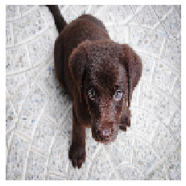

```python
pipe = Pipeline([f2,f3])
t = pipe(TEST_IMAGE)
ax = pipe.show(t)
```

```python
test_fig_exists(ax)
```

```python
#Check filtering is properly applied
add1 = B()
add1.split_idx = 1
pipe = Pipeline([neg_tfm, A(), add1])
test_eq(pipe(start), -2)
pipe.split_idx=1
test_eq(pipe(start), -1)
pipe.split_idx=0
test_eq(pipe(start), -2)
for t in [None, 0, 1]:
    pipe.split_idx=t
    test_eq(pipe.decode(pipe(start)), start)
    test_stdout(lambda: pipe.show(pipe(start)), "-2.0")
```

### Methods

```python
#TODO: method examples
```

`Pipeline.__call__`[[source]](https://github.com/fastai/fastai2/tree/master/fastai2/core/transform.py#L200)

> `Pipeline.__call__`(**`o`**)

Call self as a function.

`Pipeline.decode`[[source]](https://github.com/fastai/fastai2/tree/master/fastai2/core/transform.py#L207)

> `Pipeline.decode`(**`o`**, **`full`**=*`True`*)

`Pipeline.setup`[[source]](https://github.com/fastai/fastai2/tree/master/fastai2/core/transform.py#L191)

> `Pipeline.setup`(**`items`**=*`None`*)

During the setup, the `Pipeline` starts with no transform and adds them one at a time, so that during its setup, each transform gets the items processed up to its point and not after.